# Supporting information for Can grant evaluation still distinguish scientific excellence?

Martin Bulla and Peter Mikula created by Martin Bulla

2026-08-06 10:02:00.62127

# General note

This HTML Supporting information accompanies our paper ‘Can grant evaluation still distinguish scientific excellence?’ by navigating the repository with data and scripts, describing the data, and showing display items along with the code that generated them (accessible by clicking the `code` button at the top right above each display item).

When referring to or reusing these materials, **please cite** the corresponding preprint (Bulla et al. 2026) and this repository (Bulla and Mikula 2026).

## Repository contents

This HTML Supporting information is generated from the following repository structure:

[**Data**](https://github.com/MartinBulla/correspondence_funding/tree/main/Data) folder stores:

- [`data_MSCA.csv`](https://github.com/MartinBulla/correspondence_funding/blob/main/Data/data_MSCA.csv): contains cumulative score distributions for the EU *Marie Skłodowska-Curie Actions Postdoctoral Fellowships* for each evaluation panel (abbreviated as “ST-CHE” = “Chemistry”, “ST-ECO” = “Economics”, “ST-ENG” = “Informat. & Engineering”, “ST-ENV” = “Envi. Sci. & Geosciences”, “ST-LIF” = “Life Sciences”, “ST-MAT” = “Mathematics”, “ST-PHY” = “Physics”, “ST-SOC” = “Social Sci. & Humanities”) and call year (2018–2025), with the following columns: `Year` (of the call) and `Score` (0–100%); the remaining columns are abbreviations for each panel and contain percentages of proposals scoring at or above the given `Score`. The data were aggregated from the [EU Funding & Tenders Portal](https://ec.europa.eu/info/funding-tenders/opportunities/portal/), which contains the official “Flash information on the overall results of the call”. These reports are published annually by the European Research Executive Agency following the conclusion of the evaluation process. While individual project scores are confidential, these public summaries provide the aggregate percentages of proposals meeting or exceeding specific quality thresholds. The proposals are scored on a scale from 0 to 100%. To access the raw reports: (i) navigate to the EU Funding & Tenders Portal → Funding → Calls for proposals, (ii) in the Quick search field, enter the specific call name (e.g. HORIZON-MSCA-2024-PF-01-01), (iii) look for the data, usually under the “Topic conditions and documents” or “Updates” section. *Marie Skłodowska-Curie Actions Postdoctoral Fellowships* are evaluated as full proposals submitted jointly by the researcher and host organisation through the EU Funding & Tenders Portal. Eligible proposals are assessed after the call deadline (in September for the 2025 call) by at least three independent external experts against the *Marie Skłodowska-Curie Actions* award criteria: Excellence, Impact, and Quality and Efficiency of Implementation. Experts first evaluate proposals individually and then agree on consensus scores and comments, which form the basis of the Evaluation Summary Report and final ranking. The *Marie Skłodowska-Curie Actions* score distributions analysed here therefore represent eligible full proposals evaluated through this single-stage full-proposal procedure, rather than applications pre-selected through an initial short-proposal stage.
- [`data_HFSP.csv`](https://github.com/MartinBulla/correspondence_funding/blob/main/Data/data_HFSP.csv): contains anonymized evaluation-score data for Full Proposals submitted to the [Postdoctoral Fellowships](https://www.hfsp.org/funding/hfsp-funding/postdoctoral-fellowships) and [Research Grants](https://www.hfsp.org/funding/hfsp-funding/research-grants) schemes of the [*Human Frontier Science Program*](https://www.hfsp.org) for 2022–2025, with the following columns: `scheme` (funding scheme), `year` (of the call), `rank` (of the application in the given scheme and year) and `score` (evaluation score; 1–10). These non-public data were kindly provided by the *Human Frontier Science Program*. We transformed the scores into percentages, with 10 representing 100%, and, to match Fig. 1, calculated the percentage of evaluated proposals scoring at or above each percentage threshold. The Human Frontier Science Program evaluates both schemes through a two-stage procedure. Applicants first submit a short Letter of Intent (deadline in spring), on the basis of which scheme-specific committees select applicants invited to submit a Full Proposal (deadline in September). The score distributions analysed here therefore represent only shortlisted applications that advanced to the Full Proposal stage, not the full applicant pool. Note that the Postdoctoral Fellowships data include applications to the Long-Term Fellowships scheme, for applicants with a PhD in a biological discipline who wish to undertake a novel, frontier project in the life sciences, but not applications to the Cross-Disciplinary Fellowships scheme, which makes only approximately five awards per year. Similarly, the Research Grants data include applications to the Program scheme, but not to the Early Career scheme, which usually makes fewer than 10 awards per year.

[**R**](https://github.com/MartinBulla/correspondence_funding/tree/main/R) folder stores scripts used in the analysis:

- [`_runRmarkdown.R`](https://github.com/MartinBulla/correspondence_funding/blob/main/R/_runRmarkdown.R) generates this HTML Supporting information from [`HTML.R`](https://github.com/MartinBulla/correspondence_funding/blob/main/R/HTML.R).
- [`HTML.R`](https://github.com/MartinBulla/correspondence_funding/blob/main/R/HTML.R) is the script behind this HTML Supporting information, containing all code used to generate the paper outputs.

[**Output**](https://github.com/MartinBulla/correspondence_funding/tree/main/Output) folder stores separate files of all outputs used in the manuscript:

- HTML.html
- [Fig_1.png](https://github.com/MartinBulla/correspondence_funding/blob/main/Output/Fig_1_width-185mm.png)
- [Fig_2.png](https://github.com/MartinBulla/correspondence_funding/blob/main/Output/Fig_2_width-85mm.png)

[**Resources**](https://github.com/MartinBulla/correspondence_funding/tree/main/Resources) folder stores:

- [`_bib.bib`](https://github.com/MartinBulla/correspondence_funding/blob/main/Resources/_bib.bib) bibliography used in this HTML Supporting information
- [`styles.css`](https://github.com/MartinBulla/correspondence_funding/blob/main/Resources/styles.css) defines graphical parameters for this HTML Supporting information generation.

### License and reuse

*Author-generated materials* in this repository, including collated data, derived data, scripts, figures, outputs and HTML, are licensed under the Creative Commons Attribution 4.0 International License [CC-BY-4.0](https://github.com/MartinBulla/correspondence_funding/blob/main/LICENSE).

### Version history

- v1.0.0: The first public release of the [`correspondence_funding`](https://github.com/MartinBulla/correspondence_funding/) repository, archived for reproducibility of the first preprint version.
- v2.0.0: Archived for reproducibility of the second preprint version.

###### Code to load tools and data

```r
# TOOLS

# Packages, settings
require(data.table)
require(ggh4x)
require(ggplot2)
require(grid)
require(gridExtra)
require(here)
require(kableExtra)
require(magrittr)
require(patchwork)
require(viridis)
require(tibble)

# function
gtable_filter_remove <- function (x, name, trim = TRUE){
  matches <- !(x$layout$name %in% name)
  x$layout <- x$layout[matches, , drop = FALSE]
  x$grobs <- x$grobs[matches]
  if (trim)
    x <- gtable_trim(x)
  x
}

# constants
theme_MB = theme(
    axis.ticks = element_blank(),
    axis.ticks.length = unit(0, "pt"),

    axis.title = element_text(size = rel(0.9)),
    axis.text = element_text(size = rel(0.775)),
    axis.text.x = element_text(margin = margin(t = 3)),
    axis.text.y = element_text(margin = margin(r = 3)),

    legend.key.height = unit(0.3, "cm"),
    legend.spacing.y  = unit(0.1, "cm"),

    # bring legend closer to plot
    legend.box.spacing = unit(0, "pt"),
    legend.margin = margin(0, 1, 0, 7, unit = "pt"),

    legend.title = element_text(size = rel(0.8)),
    legend.text = element_text(size = rel(0.75)),

    legend.background = element_blank(),
    legend.box.background = element_blank(),
    legend.key = element_blank(),

    strip.text = element_text(size = rel(0.72)), #
    strip.placement = "outside",
    strip.background = element_blank(),

    #panel.spacing.x = unit(6, "pt"),  # try 6–12 pt,
    panel.border = element_rect(colour = "grey60"),
    panel.grid.major = element_line(colour = "grey95"),
    panel.grid.minor = element_blank()
  )
```

# Figures

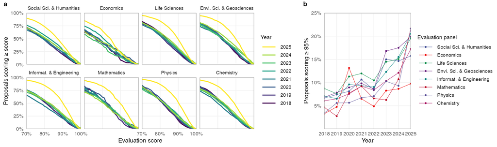

```r
# PANEL A

# define colors
pal <- colorspace::qualitative_hcl(
  n = 8,
  palette = "Dark 3"
)

# load data
dt <- fread(here::here("Data/data_MSCA.csv"))

# identify ST-columns
st_cols <- grep("^ST", names(dt), value = TRUE)

# long format
dt_long <- melt(
  dt,
  id.vars = c("Year", "Score"),
  measure.vars = st_cols,
  variable.name = "panel",
  value.name = "applications"
)

# Panel code -> full name
panel_map <- c(
  "ST-CHE" = "Chemistry",
  "ST-ECO" = "Economics",
  "ST-ENG" = "Informat. & Engineering",
  "ST-ENV" = "Envi. Sci. & Geosciences",
  "ST-LIF" = "Life Sciences",
  "ST-MAT" = "Mathematics",
  "ST-PHY" = "Physics",
  "ST-SOC" = "Social Sci. & Humanities"
)

dt_long[, panel_full := panel_map[as.character(panel)]]

panel_order <- c(
  "Social Sci. & Humanities",
  "Economics",
  "Life Sciences",
  "Envi. Sci. & Geosciences",
  "Informat. & Engineering",
  "Mathematics",
  "Physics",
  "Chemistry"
)

dt_long[, panel_full := factor(panel_full, levels = panel_order)]

dt_long[, dummy := ""] # dummy for plotting
# Ensure year is ordered (helps sequential palettes match time)
dt_long[, Year := as.integer(Year)]
dt_long[, Year_f := factor(Year, levels = sort(unique(Year)))]

# Descriptive summary
#summary(dt_long[Score%in%85 & Year == 2025])
#summary(dt_long[Score%in%85 & Year < 2025])

# plot
pA <- ggplot(
  dt_long,
  aes(x = Score, y = applications, colour = Year_f, group = Year_f)
) +
  geom_line(linewidth = 0.5) +
  facet_wrap(~ panel_full, nrow = 2) +
  labs(
    x = "Evaluation score",
    y = "Proposals scoring ≥ score",
    colour = "Year"
  ) +
  scale_colour_viridis_d() +
  guides(colour = guide_legend(reverse = TRUE)) +
  #scale_y_continuous(limits = c(0, 100),expand = expansion(mult = c(0, 0))) +
  #scale_x_continuous(limits = c(70, 100),expand = expansion(mult = c(0, 0))) +
  scale_y_continuous(
    limits = c(0, 100),
    labels = scales::label_percent(scale = 1, accuracy = 1),
    expand = expansion(mult = c(0, 0))
  ) +
  scale_x_continuous(
    limits = c(70, 100),
    labels = scales::label_percent(scale = 1, accuracy = 1),
    expand = expansion(mult = c(0, 0))
  ) +
  #scale_colour_brewer(palette = "YlGnBu") +
  #scale_colour_manual(values = colorspace::sequential_hcl(nlevels(dt_long$Year_f), palette = "BluGrn")) +

  theme_bw(base_size = 7) +
  theme_MB

pA_gr <- ggplotGrob(pA)  # view with #g_tr_des$layout$name
pA_gr <- gtable_filter_remove(pA_gr, name = c("axis-b-2-2", "axis-b-4-2"), trim = FALSE)

# PANEL B
pB <- ggplot(
  dt_long[Score%in%95],
  aes(x = Year, y = applications)
) +
  geom_line(aes(col = panel_full), linewidth = 0.15) +
  geom_point(aes(col = panel_full), cex = .5) + #, shape = 21, bg = 'white', cex = .8) +
  #stat_smooth(method = "loess", se = FALSE, linewidth = 0.5, span = 0.75, col = 'black') +
  facet_wrap(~ dummy, nrow = 1) +
  labs(
    x = "Year",
    y = "Proposals scoring ≥ 95%",
    colour = "Evaluation panel"
  ) +
  #scale_colour_manual(values = khroma::colour("muted")(8)) +
  #scale_colour_manual(values = palette.colors(8, "Okabe-Ito")) + #
  #scale_colour_carto_d(palette = "Safe") +
  ggsci::scale_colour_aaas() +
  #1ggsci::scale_colour_npg() +
  #ggsci::scale_colour_jco() +
  #scale_color_manual(values = pal) +
  #scale_colour_viridis_d() +
  #guides(colour = guide_legend(reverse = TRUE)) +
  #scale_colour_brewer(palette = "YlGnBu") +
  #scale_colour_manual(values = colorspace::sequential_hcl(nlevels(dt_long$Year_f), palette = "BluGrn")) +
  scale_y_continuous(
    limits = c(0, 25),
    breaks = seq(0, 25, by = 5),
    labels = function(x) ifelse(x == 0, "", paste0(x, "%")),
    expand = expansion(mult = c(0, 0))
  ) +
  #scale_y_continuous(limits = c(0, 25), breaks = seq(0,25, by =5), labels = c("", 5, 10, 15, 20, 25), expand = expansion(mult = c(0, 0))) +
  scale_x_continuous(limits = c(2018, 2025),breaks = seq(2018,2025, by = 1), expand = expansion(mult = c(0, 0))) +

  theme_bw(base_size = 7) +
  theme_MB

pB_gr <- ggplotGrob(pB)

# COMBINE PANELS A & B
gap <- grid::nullGrob()  # blank spacer

gg = arrangeGrob(
      grobs = list(pA_gr,gap, pB_gr),
       #widths = c(0.6, 0.4)
      widths = unit.c(unit(0.595, "npc"), unit(0.01, "npc"), unit(0.395, "npc"))
      )

gg_tagged <- grobTree(
  gg,
  textGrob("a", x = unit(0.0075, "npc"), y = unit(0.99, "npc"),
           just = c("left", "top"),
           gp = gpar(fontsize = 7, fontface = "bold")),
  textGrob("b", x = unit(0.61, "npc"), y = unit(0.99, "npc"),
           just = c("left", "top"),
           gp = gpar(fontsize = 7, fontface = "bold"))
)

# EXPORT
ggsave(here::here("Output/Fig_1_width-185mm.png"),gg_tagged, width = 18.5, height = 5.5, units = 'cm')

knitr::include_graphics(here::here("Output/Fig_1_width-185mm.png"))
```

**Figure 1** | Temporal shift and score compression in evaluations of Marie Skłodowska-Curie Actions postdoctoral fellowships. **a**, Temporal trend in the percentage of proposals scoring at or above threshold across evaluation panels. The 2025 cohort (yellow) shows a marked divergence from the tightly clustered historical distribution (2018–2024), shifting toward higher scores across all deciles. For example, the 85% ‘Seal of Excellence’ threshold was reached by ~70% of proposals in 2025, compared to ~40% in previous years (medians). n<sub>2018</sub> = 9,830 applications, n<sub>2019</sub> = 9,875, n<sub>2020</sub> = 11,573, n<sub>2021</sub> = 8,356, n<sub>2022</sub> = 7,044, n<sub>2023</sub> = 8,039, n<sub>2024</sub> = 10,360, n<sub>2025</sub> = 17,066. **b**, Temporal trend of “excellence saturation”, defined as the percentage of proposals achieving a score ≥95%. Data extracted from the [EU Funding & Tenders Portal](https://ec.europa.eu/info/funding-tenders/opportunities/portal/) and available via (Bulla and Mikula 2026).

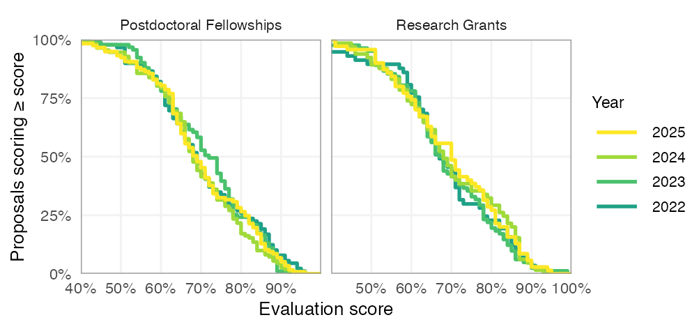

```r
# colors
year_cols <- setNames(
  viridis(8, option = "D", direction = 1),
  2018:2025
) #year_cols["2025"]


pal <-c(year_cols["2022"], year_cols["2023"], year_cols["2024"], year_cols["2025"])

# data
dt <- fread(here::here("Data/data_HFSP.csv"))
dt[, percent := 100*score/10]
dt[, year_chr := as.character(year)]
dt[, year_f := factor(year)]

# percentage of evaluated proposals scoring >= each threshold
ccdf <- dt[, {
  th <- seq(0, 100, by = 1)
  .(
    Score = th,
    applications = vapply(th, function(x) mean(percent >= x)*100, numeric(1)),
    n = .N
  )
}, by = list(scheme, year_f)]

# plot
p_hfsp <- ggplot(
  ccdf,
  aes(x = Score, y = applications, colour = year_f, group = year_f)
) +
  geom_step(linewidth = 0.6) +
  facet_wrap(~ scheme, nrow = 1, scales = 'free_x') +
  facetted_pos_scales(
    x = list(
      scheme == "Postdoctoral Fellowships" ~
        scale_x_continuous(
          limits = c(40, 100),
          breaks = seq(40, 100, by = 10),
          labels = c("40%", "50%", "60%", "70%", "80%", "90%", ""),
          expand = expansion(mult = 0)
        ),

      scheme == "Research Grants" ~
        scale_x_continuous(
          limits = c(40, 100),
          breaks = seq(40, 100, by = 10),
          labels = c("", "50%", "60%", "70%", "80%", "90%", "100%"),
          expand = expansion(mult = 0)
        )
    )
  ) +
  labs(
    x = "Evaluation score",
    y = "Proposals scoring ≥ score",
    colour = "Year"
  ) +
  scale_color_manual(values = pal) +
  #scale_colour_viridis_d() +
  guides(colour = guide_legend(reverse = TRUE)) +
  coord_cartesian(xlim = c(40, 100), ylim = c(0, 100)) +
  scale_y_continuous(
      limits = c(0, 100),
       labels = scales::label_percent(scale = 1, accuracy = 1),
      expand = expansion(mult = c(0, 0)), breaks = seq(0,100, by = 25)
      ) +

  #scale_x_continuous(labels = function(x) ifelse(x == 0, "", paste0(x, "%")), expand = expansion(mult = c(0, 0))) +
  theme_bw(base_size = 7) +
  theme_MB +
  theme(
    #legend.position = c(0.95, 0.95),
    #legend.justification = c(1, 1),
    legend.background = element_rect(fill = scales::alpha("white", 0.7), colour = NA),
    legend.key = element_blank(),
    legend.box.background = element_blank(),

    #plot.margin = margin(t = 4, r = 8)
  )

ggsave(here::here("Output/Fig_2_width-85mm.png"),p_hfsp, width = 8.5, height = 4, units = 'cm')

knitr::include_graphics(here::here("Output/Fig_2_width-85mm.png"))
```

**Figure 2** | Score distributions in evaluations of Human Frontier Science Program. Percentage of evaluated full proposals scoring at or above each evaluation-score threshold across application years (2022–2025) and funding schemes (Postdoctoral Fellowships and Research Grants). Proposal scores were originally provided on a 1–10 scale and were transformed to percentages to match the threshold-based representation used in Fig. 1. Score distributions were similar across years and between the two schemes. Postdoctoral Fellowships: n<sub>2022</sub> = 89 applications at the Full Proposal stage (out of 393 evaluated Letters of Intent), n<sub>2023</sub> = 91 (492), n<sub>2024</sub> = 111 (525), n<sub>2025</sub> = 117 (663). Research Grants: n<sub>2022</sub> = 57 (450), n<sub>2023</sub> = 82 (585), n<sub>2024</sub> = 65 (669), n<sub>2025</sub> = 70 (956). Data are available via (Bulla and Mikula 2026).

# Session info

```r
# Table S1: System session info.
df_session_platform <- devtools::session_info()$platform %>%
  unlist(.) %>%
  as.data.frame(.) %>%
  rownames_to_column(.)

colnames(df_session_platform) <- c("Item", "Value")

df_session_platform %>%
  kbl(
    caption = "Table S1 | System session info.",
    align=c('r', 'l'),
    linesep = "",
    table.attr = 'id="T_S1"'
  ) %>%
  kable_paper(c("striped", "condensed"), full_width = F, position = "left")
```

Table S1 | System session info.

| Item | Value |
| --- | --- |
| version | R version 4.5.2 (2025-10-31) |
| os | macOS Tahoe 26.5.1 |
| system | aarch64, darwin25.0.0 |
| ui | unknown |
| language | (EN) |
| collate | C.UTF-8 |
| ctype | C.UTF-8 |
| tz | Europe/Prague |
| date | 2026-08-06 |
| pandoc | 3.9.0.2 @ /opt/homebrew/bin/ (via rmarkdown) |
| quarto | NA |

```r
# Table S2: Info about used packages.
df_session_packages <- devtools::session_info()$packages %>%
  as.data.frame(.) %>%
  # filter(attached == TRUE) %>%
  dplyr::select(loadedversion, date, source) %>%
  rownames_to_column()

colnames(df_session_packages) <- c("Package", "Loaded version", "Date", "Source")
df_session_packages %>%
  kbl(
    caption = "Table S2 | Info about used packages.",
    align = c("l", "l","l","l"),
    linesep = "",
    table.attr = 'id="T_S2"'
  ) %>%
  kable_paper(c("striped", "condensed"), full_width = F, position = "left") %>%
  scroll_box(height = "650px") #width = "90%",
```

Table S2 | Info about used packages.

| Package | Loaded version | Date | Source |
| --- | --- | --- | --- |
| bslib | 0.10.0 | 2026-01-26 | CRAN (R 4.5.2) |
| cachem | 1.1.0 | 2024-05-16 | CRAN (R 4.5.2) |
| cli | 3.6.6 | 2026-04-09 | CRAN (R 4.5.2) |
| colorspace | 2.1-2 | 2025-09-22 | CRAN (R 4.5.2) |
| data.table | 1.18.2.1 | 2026-01-27 | CRAN (R 4.5.2) |
| devtools | 2.5.0 | 2026-03-14 | CRAN (R 4.5.2) |
| dichromat | 2.0-0.1 | 2022-05-02 | CRAN (R 4.5.2) |
| digest | 0.6.39 | 2025-11-19 | CRAN (R 4.5.2) |
| dplyr | 1.2.0 | 2026-02-03 | CRAN (R 4.5.2) |
| ellipsis | 0.3.2 | 2021-04-29 | CRAN (R 4.5.2) |
| evaluate | 1.0.5 | 2025-08-27 | CRAN (R 4.5.2) |
| farver | 2.1.2 | 2024-05-13 | CRAN (R 4.5.2) |
| fastmap | 1.2.0 | 2024-05-15 | CRAN (R 4.5.2) |
| fs | 2.0.1 | 2026-03-24 | CRAN (R 4.5.2) |
| generics | 0.1.4 | 2025-05-09 | CRAN (R 4.5.2) |
| ggh4x | 0.3.1 | 2025-05-30 | CRAN (R 4.5.2) |
| ggplot2 | 4.0.3 | 2026-04-22 | CRAN (R 4.5.2) |
| ggsci | 4.2.0 | 2025-12-17 | CRAN (R 4.5.2) |
| glue | 1.8.1 | 2026-04-17 | CRAN (R 4.5.2) |
| gridExtra | 2.3 | 2017-09-09 | CRAN (R 4.5.2) |
| gtable | 0.3.6 | 2024-10-25 | CRAN (R 4.5.2) |
| here | 1.0.2 | 2025-09-15 | CRAN (R 4.5.2) |
| htmltools | 0.5.9 | 2025-12-04 | CRAN (R 4.5.2) |
| jquerylib | 0.1.4 | 2021-04-26 | CRAN (R 4.5.2) |
| jsonlite | 2.0.0 | 2025-03-27 | CRAN (R 4.5.2) |
| kableExtra | 1.4.0 | 2024-01-24 | CRAN (R 4.5.2) |
| knitr | 1.51 | 2025-12-20 | CRAN (R 4.5.2) |
| labeling | 0.4.3 | 2023-08-29 | CRAN (R 4.5.2) |
| lifecycle | 1.0.5 | 2026-01-08 | CRAN (R 4.5.2) |
| magrittr | 2.0.4 | 2025-09-12 | CRAN (R 4.5.2) |
| memoise | 2.0.1 | 2021-11-26 | CRAN (R 4.5.2) |
| otel | 0.2.0 | 2025-08-29 | CRAN (R 4.5.2) |
| patchwork | 1.3.2 | 2025-08-25 | CRAN (R 4.5.2) |
| pillar | 1.11.1 | 2025-09-17 | CRAN (R 4.5.2) |
| pkgbuild | 1.4.8 | 2025-05-26 | CRAN (R 4.5.2) |
| pkgconfig | 2.0.3 | 2019-09-22 | CRAN (R 4.5.2) |
| pkgload | 1.5.0 | 2026-02-03 | CRAN (R 4.5.2) |
| png | 0.1-9 | 2026-03-15 | CRAN (R 4.5.2) |
| purrr | 1.2.1 | 2026-01-09 | CRAN (R 4.5.2) |
| R6 | 2.6.1 | 2025-02-15 | CRAN (R 4.5.2) |
| ragg | 1.5.2 | 2026-03-23 | CRAN (R 4.5.2) |
| RColorBrewer | 1.1-3 | 2022-04-03 | CRAN (R 4.5.2) |
| rlang | 1.2.0 | 2026-04-06 | CRAN (R 4.5.2) |
| rmarkdown | 2.31 | 2026-03-26 | CRAN (R 4.5.2) |
| rprojroot | 2.1.1 | 2025-08-26 | CRAN (R 4.5.2) |
| rstudioapi | 0.18.0 | 2026-01-16 | CRAN (R 4.5.2) |
| S7 | 0.2.2 | 2026-04-22 | CRAN (R 4.5.2) |
| sass | 0.4.10 | 2025-04-11 | CRAN (R 4.5.2) |
| scales | 1.4.0 | 2025-04-24 | CRAN (R 4.5.2) |
| sessioninfo | 1.2.3 | 2025-02-05 | CRAN (R 4.5.2) |
| stringi | 1.8.7 | 2025-03-27 | CRAN (R 4.5.2) |
| stringr | 1.6.0 | 2025-11-04 | CRAN (R 4.5.2) |
| svglite | 2.2.2 | 2025-10-21 | CRAN (R 4.5.2) |
| systemfonts | 1.3.2 | 2026-03-05 | CRAN (R 4.5.2) |
| textshaping | 1.0.5 | 2026-03-06 | CRAN (R 4.5.2) |
| tibble | 3.3.1 | 2026-01-11 | CRAN (R 4.5.2) |
| tidyselect | 1.2.1 | 2024-03-11 | CRAN (R 4.5.2) |
| usethis | 3.2.1 | 2025-09-06 | CRAN (R 4.5.2) |
| vctrs | 0.7.3 | 2026-04-11 | CRAN (R 4.5.2) |
| viridis | 0.6.5 | 2024-01-29 | CRAN (R 4.5.2) |
| viridisLite | 0.4.3 | 2026-02-04 | CRAN (R 4.5.2) |
| withr | 3.0.2 | 2024-10-28 | CRAN (R 4.5.2) |
| xfun | 0.57 | 2026-03-20 | CRAN (R 4.5.2) |
| xml2 | 1.5.2 | 2026-01-17 | CRAN (R 4.5.2) |
| yaml | 2.3.12 | 2025-12-10 | CRAN (R 4.5.2) |

# References

Bulla, M., and P. Mikula. 2026. “Supporting Information for ’Can Grant Evaluation Still Distinguish Scientific Excellence?’.” *GitHub*. https://martinbulla.github.io/correspondence_funding/.

Bulla, M., J. Wilsdon, and P. Mikula. 2026. “Can Grant Evaluation Still Distinguish Scientific Excellence?” *MetaArXiv*. https://osf.io/preprints/metaarxiv/d8gcu_v2.